# 10 sitios para aprender [gratis] Git!

Metodologias

Si quieres aprender Git aquí te dejo recursos para poder lograr este objetivo.

Romina Mendez https://r0mymendez.github.io/romymendezblog/  
07-23-2022

[figure not shown]

Si quieres aprender Git aquí te dejo recursos para poder lograr este objetivo.

## ¿Que es Git?

**Git** es un sistema de control de versiones de código abierto que permite manejar y realizar control de versiones en proyectos de desarrollo de software. Fue desarrollado en 2005 por **Linus Torvalds**, el creador de del kernel de sistema operativo de Linux.

[figure not shown]

## **Control de versiones**

En la siguiente imagen se puede ver un simple ejemplo de un documento que fue modificado varias veces y cada version nueva tiene una nueva denominación.

Este mismo ejemplo se puede reproducir en un equipo, donde varios desarrolladores modifican un mismo documento. Esto trae como consecuencia la dificultad de gestionar los cambios y problemas para documentar el porque de las modificaciones.

Debido a esto Git es una herramienta que nos permite trabajar de forma ordenada, con un equipo de desarrollo y sin preocuparnos de tener multiples versiones del mismo documento.

[figure not shown]

Phdcomics.com: https://twitter.com/phdcomics/status/1306536945980383232

# **Como aprender Git**

A continuación te dejo 10 sitios para poder aprender Git de manera gratuita.

## [**1. Codeacademy**](https://www.codecademy.com/learn/learn-git)

Codeacademy es una plataforma de cursos de desarrollo y uno de ellos permite aprender git con una consola online y contiene 12 capítulos con ejercicios para realizar.

[figure not shown]

## [**2. Git Documentation**](https://git-scm.com/doc)

En el sitio web oficial de git existe la documentación disponible con video y tutoriales para poder aprender fácilmente.

## [**3. Oh my git**](https://ohmygit.org/)

Es un juego interactivo, el cual es un desarrollo de código abierto y tiene como objetivo realizar diferentes desafios y aprender como trabajar con git.

[figure not shown]

https://ohmygit.org/

## [4. Git cheat sheet](https://training.github.com/downloads/github-git-cheat-sheet.pdf)

Esta es una cheet sheet en pdf que te permite recordar los comando básicos y una breve explicación de como utilizarlos .

Este documento lo puedes descargar en varios idiomas incluyendo español e ingles.

[figure not shown]

## [**5. Atlassian Tutorial**](https://www.atlassian.com/git/tutorials/learn-git-with-bitbucket-cloud)

Atlassian tiene varios libros online en ingles y español que permite aprender git y como implementarlo utilizando bitbucket cloud.

## [**6. Rstudio Git**](https://ecodatasci-tlv.github.io/git-rmd/pres.html#1)

Rstudio que es una IDE que permite el desarrollo principalmente en lenguaje R, aunque actualmente soporta varios lenguajes adicionales tales como python, permite versionar codigo con git.

[figure not shown]

## [**7. Happy git with r**](https://happygitwithr.com/)

Para desarrolladores de R también tenemos este sitio con más de 40 capítulos en cual muestra como implementar git en un proyecto de R.

## [**8. Learn Git Branching**](https://learngitbranching.js.org/?locale=es_AR)

Esta aplicación te permite aprender de manera interactiva a trabajar con ramas en git

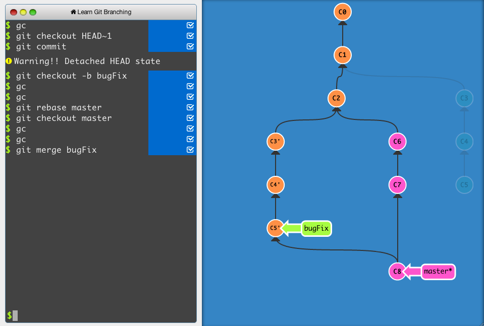

## [**9. Git Tower Book**](https://www.git-tower.com/learn/git/ebook)

Es un libro online con varios capítulos desde los introductorios hasta los más avanzados para aprender como implementar la git en un proyecto de desarrollo.

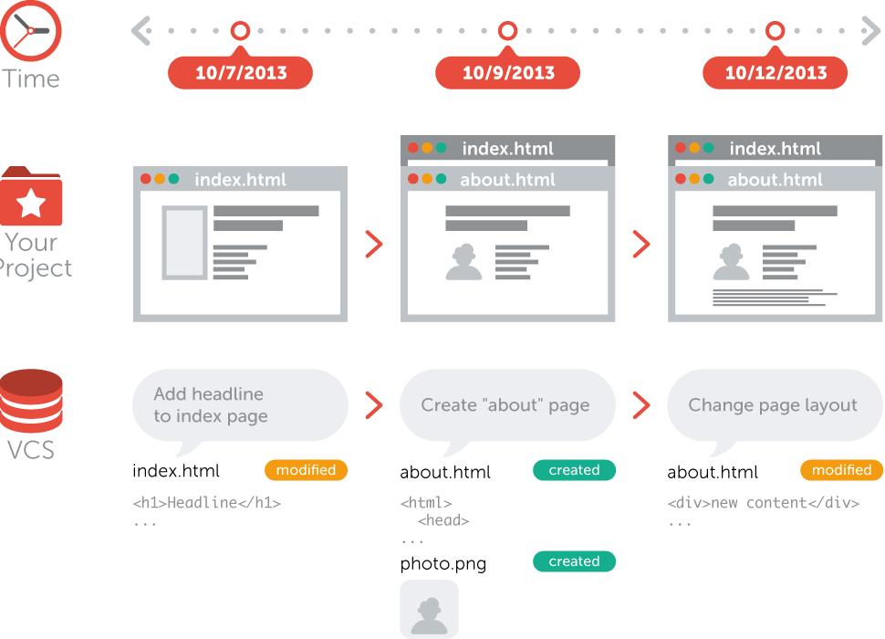

https://www.git-tower.com/learn/git/ebook/en/desktop-gui/basics/what-is-version-control

## [**10. W3shcools**](https://www.w3schools.com/git/)

Es una plataforma para aprender a programar en varios lenguajes, pero también posee ejercicios que se pueden resolver desde una consola desde la misma web y aprender de forma interactiva.

Adicionalmente posee un examen para con varias preguntas para evaluar tu conocimiento sobre Git.

### Otras referencias:

1. GIT: https://git-scm.com/
2. What is GIT?: https://www.atlassian.com/es/git/tutorials/what-is-git